# Dynamic Games

Matteo Courthoud

2021-10-29

## Model

### Intro

Setting: agents making **strategic decisions** in **dynamic environments**.

- Entry and exit: Collard-Wexler (2013)
- Sunk costs: Ryan (2012)
- Innovation: Igami (2017)
  - (or whatever changes in response to investment)
- Learning-by-doing
- Switching costs
- Stockpiling: Hendel and Nevo (2006)

### Simple Example

Lousely taken from Ericson and Pakes (1995)

- Builds on Maskin and Tirole (1988), Maskin and Tirole (1988), Maskin and Tirole (1987)
- Firms invest to increase the future quality of their product
- State $s_{it}$: quality of product $i$ in period $t$
- Per period profits
  $$\pi ( s_{it}, s_{-it}, ; \theta^\pi)$$
  where
  - $s_{-it}$: state vector of all other firms in period $t$
  - $\theta^\pi$: parameters that govern static profits
- We can micro-fund profits with some demand and supply functions

### Dynamic Decisions

In each period firms have 3 choices (in order)

1. If entrant, $e_{it}$: whether to enter the market or not
2. If incumbent, $d_{it}$: whether to exit the market or not
3. If incumbent, $a_{it}$: investment
   - Influences your state transition probability $f$
     $$s_{i, t+1} = f(s_{it}, a_{it}, \epsilon_{it} ; \theta^f)$$
     where
     - $\epsilon_{it}$: shock that is not known to the firm when making the decision
       - it does not need to be there
     - $\theta^f$: parameters that govern state transitions
   - Example of transition
     $$s_{i, t+1} = \delta s_{it} + a_{it} + \epsilon_{it}$$
     I.e. depreciation of capital + investment and noise

### Value Function

Belman Equation incumbent $i$ at time $t$
$$\begin{aligned}
V (s_{i t}, s_{-i t} ; \theta) = & \pi(s_{i t}, s_{-i t} ; \theta^{\pi}) + \max_{d_{i} \in \lbrace 0,1 \rbrace}
\Bigg\lbrace
\begin{array}{c}
\beta \phi \ ; \newline
\max _{a_{i t} \geq 0} \Big\lbrace - a_{i t} + \beta \mathbb E \Big[V (s_{i, t+1}, s_{-i, t+1} \ ; ] \theta) \Big| s_{i t}, s_{-i t}, a_{i t} \Big] \Big\rbrace
\end{array}
\Bigg\rbrace
\end{aligned}$$
where

- $\beta \in (0,1)$: discount factor
- $\phi$: exit scrap value
- $a_{it} \in \mathbb R_+$: investment decision, in dollars
- $d_{it} \in \lbrace 0,1 \rbrace$: exit decision
- The expectation $\mathbb E$ is over
  - The shocks $\epsilon_{it}$
  - Rivals future states $s_{-i,t+1}$

### Entry

We can also incorporate endogenous entry.

- One or more **potential entrants** exist outside the market
- They can pay an entry cost $\kappa$ and enter the market at a quality state $\bar s$

Value function
$$V^{\text {e}} (s_{i t}, s_{-i t} ; \theta) = \max_{e \in \lbrace 0,1 \rbrace }
\Bigg\lbrace
\begin{array}{c}
0 \ ; \newline
-\kappa + \beta \mathbb E \Big[ V(\bar s, s_{-i, t+1} ; \theta) \Big| s_{t} \Big]
\end{array}
\Bigg\rbrace$$
where

- $e \in \lbrace 0,1 \rbrace$: entry decision
- $\kappa$: entry cost

Do we observe potential entrants?

- Igami (2017): tech industry announce their entry
- Critique: not really potential entrants, they are half-way inside

### Equilibrium

Equillibrium notion: **Markow Perfect Equilibrium** (Maskin and Tirole 1988)

- A set value, policy functions and transition probabilities
  $$\Big \lbrace \ V(\cdot), \ V^{e n t}(\cdot), \ d(\cdot), \ a(\cdot), \ e(\cdot), \ f(s_{-i, t+1} | s_{t}) \ \Big \rbrace$$
  such that
  1. $V(\cdot), \ V^{e n t}(\cdot), \ d(\cdot), \ a(\cdot), \ e(\cdot)$ solve their respective equations *given* $f(s_{-i, t+1} | s_{t})$
  2. the transition probabilities $f(s_{-i, t+1} | s_{t})$ are generated by the strategies $d(\cdot), \ a(\cdot), \ e(\cdot)$

What is it basically?

- Nash Equilibrium in the policy functions
- What are we ruling out?
  - Strategies that depend on longer histories
  - E.g. “has anyone ever cheated in a cartel?”

### Solving the model

Numerically!

1. Given parameter values $\theta$
2. Start with a guess for the value and policy functions
3. They will imply some transition probabilities
4. That will imply some new policies and so on…
5. … until what?

**Issues**

- No guarantee of convergence
  - Doraszelski and Satterthwaite (2010): prove existence of MPE with random costs/scrap values
  - The BR iteration can never find mixed-strategy equilibria
- Multiple equilibria issues
- Curse of dimensionality (computational issue, not conceptual)

### Multiple Equilibria

- Besanko et al. (2010) and Borkovsky, Doraszelski, and Kryukov (2010): homotopy method
  - can find some equilibria
  - not all
  - complicated to implement
- Iskhakov et al. (2017): grid method
  - can find all equilibria
  - but for very specific class of dynamic games
  - must always proceed “forward”
    - e.g. either entry or exit but not both
- Pesendorfer and Schmidt-Dengler (2010): the BR iteration cannot find all possible equilibria, because some equilibria are not Lyapunov-stable, which means you cannot find one unless you start your numerical search from the exact solution
- Su and Judd (2012) and Egesdal, Lai, and Su (2015): show this point numerically, by using their proposed Mathematical Programming with Equilibrium Constraints (MPEC) approach.

### Curse of Dimensionality

Two potential solutions:

1. **Computational**: approximate the equilibrium
   - Doraszelski and Judd (2019): games with random moves
   - Farias, Saure, and Weintraub (2012): solve the global problem approximately
2. **Conceptual**: define another game
   - Weintraub, Benkard, and Van Roy (2008): oblivious equilibrium
   - Pakes and McGuire (2001) and Fershtman and Pakes (2012): experience-based equilibrium
   - Doraszelski and Judd (2012): games in continuous time

## Estimation - Bajari, Benkard, Levin (2008)

### Methods

We want to estimate 3 sets of **parameters**:

- $\theta^\pi$: parameterizes period profit function $\pi()$
- $\theta^f$: parameterizes state transition function $f()$
- $\theta^{ddc}$: scrap value $\phi$ and entry cost $\kappa$

Generally 2 **approaches**

1. Full solution
   - Impractical
2. Hotz and Miller (1993) CCP inversion
   - Aguirregabiria and Mira (2007)
   - Bajari, Benkard, and Levin (2007)
   - Pakes, Ostrovsky, and Berry (2007)
   - Pesendorfer and Schmidt-Dengler (2008)

### BBL: First Stage

First stage: estimate the policy functions (CCP) non-parametrically

- Directly retrievable from data
  - Entry decisions $\hat e (s_{i t}, s_{-i t})$
  - Exit decisions $\hat d (s_{i t}, s_{-i t})$
  - Investment decisions $\hat a (s_{i t}, s_{-i t})$
  - Transition probabilities $\hat f (s_{i t}, s_{-i t} ; \theta^f)$
- Conditional on having enough data
  - **Note**: need to estimate choice probabilities, conditional on each state
  - Problem with many states but especially with many players
    - Curse of dimensionality
  - Problem especially for transition probabilities: state $\times$ state
- Important to do it non-parametrically: parametric assumptions would contradict the model for the estimation of value/polify functions

### BBL: Second Stage

We now have the policy functions, CCPs and state transition probabilities

- We can use them together to simulate **histories**
- If we have a candidate value of $\theta^\pi$, we can compute static payoffs
- Simulated history + static payoffs = simualted value function
- We can average over may simulated value functions to get an **expected value function**

What is the objective function?

- Potentially many options
- We want parameters that give firms the highest values, given those strategies (CCPs)

### In Practice

Take a parameter $\theta$.

For many simulations do:

- Initialize firms value to zero
- Fot $t=0 ... \infty$ do
  - For each state do:
    - For each firm do:
      - Compute static profits $\pi(s_{i t}, s_{-i t} ; \theta^{\pi})$
      - Compute firms actions using $\hat a (s_{i t}, s_{-i t})$ and $\hat d (s_{i t}, s_{-i t})$
      - If firm exits, $\hat d = 0$, end
      - If not, $\hat d = 1$, subtract $a_{i,t}$ from profits
      - Use $\hat f (s_{i t}, s_{-i t} ; \theta^f)$ to *simulate* next state for firm $i$
      - Add discounted profits to the value function $\beta^t \pi(s_{i t}, s_{-i t} ; \theta^{\pi})$
    - Use the next state, $(s_{i t+1}, s_{-i t+1})$ as current state for the next iteration

Then average all the value functions together to obtain an **expected value function** $\mathbb E \Big[ V (s_{i t}, s_{-i t} ; \theta) \Big]$

- **Note**: advantage of simulations: can be parallelized

### Objective Function

**Idea**

- If the observed choices $\hat a (s_{i t}, s_{-i t})$ and $\hat d (s_{i t}, s_{-i t})$ are optimal,
  - All other choices $\tilde a (s_{i t}, s_{-i t})$ and $\tilde d (s_{i t}, s_{-i t})$
  - At the true parameters $\theta$
  - Should give a lower expected value
    $$\mathbb E \Big[ \tilde V (s_{i t}, s_{-i t} ; \theta) \Big] \leq \mathbb E \Big[ V (s_{i t}, s_{-i t} ; \theta) \Big]$$
- So which are the true parameters?
  - Those for which any deviation from the policy yields a lowe value
  - **Objective function**: minimize the violations
    $$\hat{\theta}= \arg \min_{\theta} \sum_{\left(s_{i t}, s_{-i t}\right)} \sum_{(\tilde{a}, \tilde{d})} \Bigg[\min \bigg\lbrace \mathbb E \Big[ \tilde V (s_{i t}, s_{-i t} ; \theta) \Big] - \mathbb E \Big[ V (s_{i t}, s_{-i t} ; \theta) \Big], 0 \bigg\rbrace \Bigg]^{2}$$

### Comments

**Objective function**: minimization of the violations for any other policy
$$\hat{\theta}= \arg \min_{\theta} \sum_{\left(s_{i t}, s_{-i t}\right)} \sum_{(\tilde{a}, \tilde{d})} \Bigg[\min \bigg\lbrace \mathbb E \Big[ \tilde V (s_{i t}, s_{-i t} ; \theta) \Big] - \mathbb E \Big[ V (s_{i t}, s_{-i t} ; \theta) \Big], 0 \bigg\rbrace \Bigg]^{2}$$

- $\min \lbrace g(\cdot), 0 \rbrace$ to pick only the violations
  - If inequality is respected, we can ignore
  - Doesn’t matter by how much you respect the inequality
- Which perturbation $\tilde a (s_{i t}, s_{-i t})$ and $\tilde d (s_{i t}, s_{-i t})$ ?
  - In principle, any perturbation is ok
  - But in practice, if we perturbe it too much, we can go too far off
  - Tip 1: start with *very small perturbations*
  - Tip 2: use perturbation that sensibly affect the dynamics
    - E.g. exiting less in states with already low exit probability is probably irrelevant

### Problems

1. Computational **curse of dimensionality** is gone (in the state space)
   - But we have a curse of dimensionality in data
   - Need a lot of markets because **now 1 market is 1 observation**
2. **Multiple equilibria**??
   - We are basically assuming it away
   - Estimating the CCPs in the first stage we assume that is the equilibrium tht is played in all markets at all times
   - To run counterfactuals, we still need to solve the model
3. Unobserved heterogeneity
   - Kasahara and Shimotsu (2009): how to identify the (minimum) number of unobserved types
   - Arcidiacono and Miller (2011): how to use an EM algorithm for the 1st stage estimation with unobserved types, conditional on the number of types
   - S. T. Berry and Compiani (2021): instrumental variables approach, relying on observed states in the distant past
4. **Non-stationarity**
   - If we have a long time period, something fundamentally might have changed

## Igami, Uetake (2019)

### Question

**Q**: *how much should an industry be allowed to consolidate?*

- Normally analyzed statically
- Static trade-offs
  - Price effects
  - Synergies (scale economies?)
- However, mergers are not exogenous events
- Dynamic trade-offs
  - Demsetz (1973): monopoly as a winner of an innovation race
  - S. Berry and Pakes (1993): any dynamic benefit could offset static inefficiences
  - Gilbert and Greene (2014): FTC and DOJ always *try* to assess “impact on innovation”

### Dynamic Trade-offs

With mergers, entry and exit

- Statically
  - Price effects (-)
  - Synergies (+)
- Ex-post effects
  - Regress mergers on competition (HHI)? 🙅🙅🙅
  - Innovation: literature finds almost anything (+/-/invU/plateau)
- Dynamic
  - The potential for a merger can induce more ex-ante innovation and ex-ante entry

**This Paper**

- **Model**: mergers, innovation, entry and exit in the HD industry
- **Objective**: study optimal merger policy

### Empirical Issues

On the dynamics

- Mergers are rare events $=$ no experiment $\to$ need a model
- Dynamic games $=$ multiple equilibria $\to$ no “full solution”
- Innovative industries $=$ global & nonstationary$\to$ no “2-step”estimation
  - we have 1 market $\leftrightarrow$ 1 data point

**Solution**

- Random moves
- Like Rust

### Model

**State** $\omega_{it}$: productivity of firm $i$ at time $t$

**Actions**

- Exit
  - Get a scrap value $\kappa^e$
  - Exit the industry
- Idle
  - No cost
  - Productivity stays the same
- Innovation
  - Pay innovation cost $\kappa^i$
  - Productivity increases stochastically: $\omega_{i,t+1} = \omega_{i,t+1} + 1$
- Merger
  - pay a merger cost $\kappa^m$
  - Get the maximum productivity of both firms $\omega_{i,t+1} = \max \lbrace \omega_{it}, \omega_{jt} \rbrace$

### Timeline

Timing of moves, within a period

1. Nature picks a mover $i$ uniformly at random
2. Firm $i$ market a take-it-or-leave-it offer
3. All active firms get payoffs $\pi_{it} (\omega_t)$
4. State transitions realize from $\omega_t$ to $\omega_{t+1}$
   - Stochastic Poisson synergy $\Delta{ijt}$
   - You might jump up more than 1 level

Finite horizon $T (=2025)$!

**Equilibrium**

- Unique sequential equilibrium
- In practice, it’s a single agent problem
- Can be solved by backward induction

### Motivating Evidence (1):

Expansion in the 80s followed by a lot of consolidation.

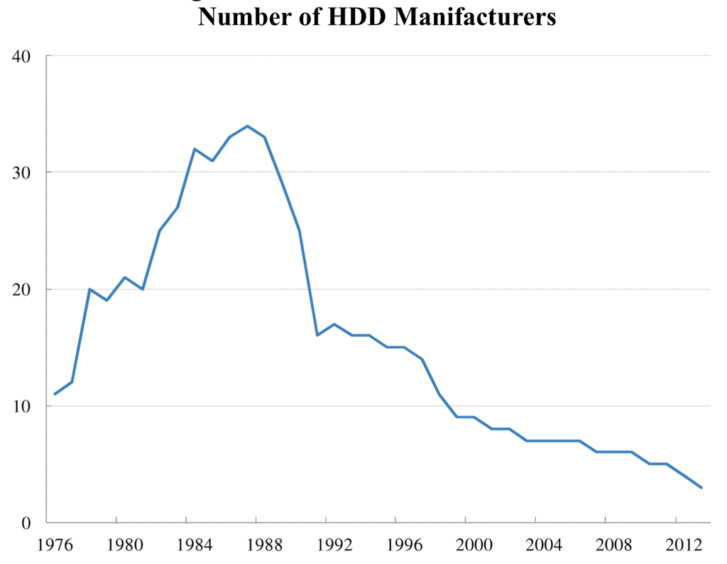

### Motivating Evidence (2)

Consolidation or exit?

- In the 80/90s mostly exit
- Then mergers

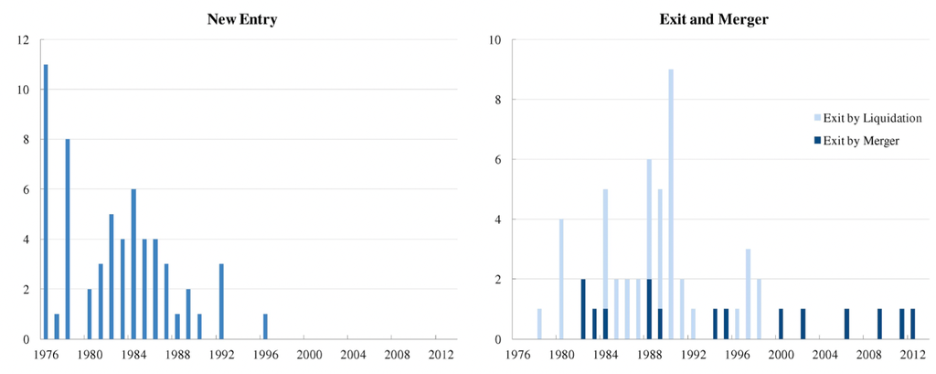

### Steps

- Estimate **demand** $(\alpha_0, \alpha_1, \alpha_2)$
  - Log-linear specification: $\log Q_{t}=\alpha_{0}+\alpha_{1} \log P_{t}+\alpha_{2} \log X_{t}+\varepsilon_{t}$
  - IV $Z_t$: input cost, disk price
- Compute marginal costs $mc_{it}$
  - Cournot competition
  - Invert the first-order condition and back out marginal costs: $mc_{it} = p_{it} + \frac{\partial p}{\partial q} q_{it}$
- Estimate **sunk costs** $(\kappa^i, \kappa^m, \kappa^e)$
  - Keane and Wolpin (1997) kind of routine
    - Pick a parameter value
    - Solve the game by backward induction
    - Compute CCPs
    - Compute likelihood
  - Estimate parameter by maximum likelihood

### FAQ

- **State space**?
  - Marginal cost of firms
  - As if in the first step we are estimating the state space
  - Only in the second step we have the dynamics
- How to deal with the **sequential moves**?
  - Split the time frame into sufficiently granular time spans
  - So that there is never 2 actions occurring at the same time
- How to deal with **periods where nothing happens**?
  - Could be that nobody moves
  - Or some mergers are tried and failed
- **Bargaining power**?
  - Mergers ar erare events: sensitivity analysis

### Results (1): Model Fit

Model fits data reasonably well

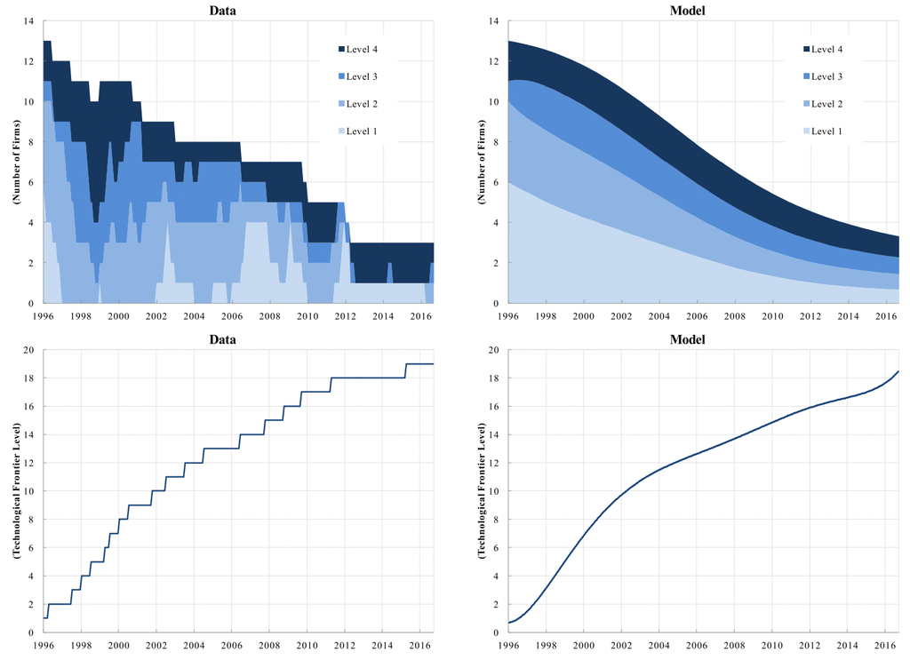

### Results (2): Mergers and Innovation

What is the estimated innovation curve?

- Plateau: increasing concave returns from innnovation in the number of (identical) firms

Incentives to merge?

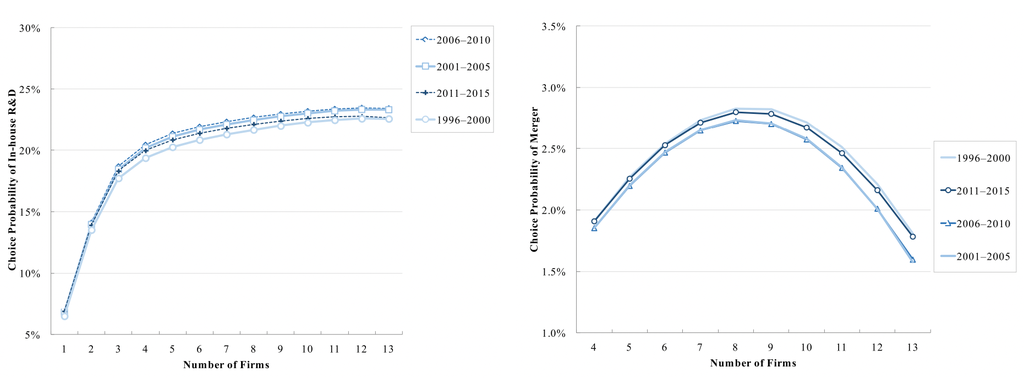

## References

Aguirregabiria, Victor, and Pedro Mira. 2007. “Sequential Estimation of Dynamic Discrete Games.” *Econometrica* 75 (1): 1–53.

Arcidiacono, Peter, and Robert A Miller. 2011. “Conditional Choice Probability Estimation of Dynamic Discrete Choice Models with Unobserved Heterogeneity.” *Econometrica* 79 (6): 1823–67.

Bajari, Patrick, C Lanier Benkard, and Jonathan Levin. 2007. “Estimating Dynamic Models of Imperfect Competition.” *Econometrica* 75 (5): 1331–70.

Berry, Steven T, and Giovanni Compiani. 2021. “Empirical Models of Industry Dynamics with Endogenous Market Structure.” *Annual Review of Economics* 13.

Berry, Steven, and Ariel Pakes. 1993. “Some Applications and Limitations of Recent Advances in Empirical Industrial Organization: Merger Analysis.” *The American Economic Review* 83 (2): 247–52.

Besanko, David, Ulrich Doraszelski, Yaroslav Kryukov, and Mark Satterthwaite. 2010. “Learning-by-Doing, Organizational Forgetting, and Industry Dynamics.” *Econometrica* 78 (2): 453–508.

Borkovsky, Ron N, Ulrich Doraszelski, and Yaroslav Kryukov. 2010. “A User’s Guide to Solving Dynamic Stochastic Games Using the Homotopy Method.” *Operations Research* 58 (4-part-2): 1116–32.

Collard-Wexler, Allan. 2013. “Demand Fluctuations in the Ready-Mix Concrete Industry.” *Econometrica* 81 (3): 1003–37.

Demsetz, Harold. 1973. “Industry Structure, Market Rivalry, and Public Policy.” *The Journal of Law and Economics* 16 (1): 1–9.

Doraszelski, Ulrich, and Kenneth L Judd. 2012. “Avoiding the Curse of Dimensionality in Dynamic Stochastic Games.” *Quantitative Economics* 3 (1): 53–93.

———. 2019. “Dynamic Stochastic Games with Random Moves.” *Quantitative Marketing and Economics* 17 (1): 59–79.

Doraszelski, Ulrich, and Mark Satterthwaite. 2010. “Computable Markov-Perfect Industry Dynamics.” *The RAND Journal of Economics* 41 (2): 215–43.

Egesdal, Michael, Zhenyu Lai, and Che-Lin Su. 2015. “Estimating Dynamic Discrete-Choice Games of Incomplete Information.” *Quantitative Economics* 6 (3): 567–97.

Ericson, Richard, and Ariel Pakes. 1995. “Markov-Perfect Industry Dynamics: A Framework for Empirical Work.” *The Review of Economic Studies* 62 (1): 53–82.

Farias, Vivek, Denis Saure, and Gabriel Y Weintraub. 2012. “An Approximate Dynamic Programming Approach to Solving Dynamic Oligopoly Models.” *The RAND Journal of Economics* 43 (2): 253–82.

Fershtman, Chaim, and Ariel Pakes. 2012. “Dynamic Games with Asymmetric Information: A Framework for Empirical Work.” *The Quarterly Journal of Economics* 127 (4): 1611–61.

Gilbert, Richard J, and Hillary Greene. 2014. “Merging Innovation into Antitrust Agency Enforcement of the Clayton Act.” *Geo. Wash. L. Rev.* 83: 1919.

Hendel, Igal, and Aviv Nevo. 2006. “Measuring the Implications of Sales and Consumer Inventory Behavior.” *Econometrica* 74 (6): 1637–73.

Hotz, V Joseph, and Robert A Miller. 1993. “Conditional Choice Probabilities and the Estimation of Dynamic Models.” *The Review of Economic Studies* 60 (3): 497–529.

Igami, Mitsuru. 2017. “Estimating the Innovator’s Dilemma: Structural Analysis of Creative Destruction in the Hard Disk Drive Industry, 1981–1998.” *Journal of Political Economy* 125 (3): 798–847.

Iskhakov, Fedor, Thomas H Jørgensen, John Rust, and Bertel Schjerning. 2017. “The Endogenous Grid Method for Discrete-Continuous Dynamic Choice Models with (or Without) Taste Shocks.” *Quantitative Economics* 8 (2): 317–65.

Kasahara, Hiroyuki, and Katsumi Shimotsu. 2009. “Nonparametric Identification of Finite Mixture Models of Dynamic Discrete Choices.” *Econometrica* 77 (1): 135–75.

Keane, Michael P, and Kenneth I Wolpin. 1997. “The Career Decisions of Young Men.” *Journal of Political Economy* 105 (3): 473–522.

Maskin, Eric, and Jean Tirole. 1987. “A Theory of Dynamic Oligopoly, III: Cournot Competition.” *European Economic Review* 31 (4): 947–68.

———. 1988. “A Theory of Dynamic Oligopoly, II: Price Competition, Kinked Demand Curves, and Edgeworth Cycles.” *Econometrica: Journal of the Econometric Society*, 571–99.

Pakes, Ariel, and Paul McGuire. 2001. “Stochastic Algorithms, Symmetric Markov Perfect Equilibrium, and the ‘Curse’of Dimensionality.” *Econometrica* 69 (5): 1261–81.

Pakes, Ariel, Michael Ostrovsky, and Steven Berry. 2007. “Simple Estimators for the Parameters of Discrete Dynamic Games (with Entry/Exit Examples).” *The RAND Journal of Economics* 38 (2): 373–99.

Pesendorfer, Martin, and Philipp Schmidt-Dengler. 2008. “Asymptotic Least Squares Estimators for Dynamic Games.” *The Review of Economic Studies* 75 (3): 901–28.

———. 2010. “Sequential Estimation of Dynamic Discrete Games: A Comment.” *Econometrica* 78 (2): 833–42.

Ryan, Stephen P. 2012. “The Costs of Environmental Regulation in a Concentrated Industry.” *Econometrica* 80 (3): 1019–61.

Su, Che-Lin, and Kenneth L Judd. 2012. “Constrained Optimization Approaches to Estimation of Structural Models.” *Econometrica* 80 (5): 2213–30.

Weintraub, Gabriel Y, C Lanier Benkard, and Benjamin Van Roy. 2008. “Markov Perfect Industry Dynamics with Many Firms.” *Econometrica* 76 (6): 1375–1411.